# 8 Visualize - Layers

# 9.5 Statistical transformations

```
Bar charts, histograms, and frequency polygons bin your data and then plot bin counts, the number of points that fall in each bin.

Smoothers fit a model to your data and then plot predictions from the model.

Boxplots compute the five-number summary of the distribution and then display that summary as a specially formatted box.
```

You can learn which stat a geom uses by inspecting the default value for the stat argument. For example, ?geom_bar shows that the default value for stat is “count”, which means that geom_bar() uses stat_count(). stat_count() is documented on the same page as geom_bar(). If you scroll down, the section called “Computed variables” explains that it computes two new variables: count and prop.

[output not shown]

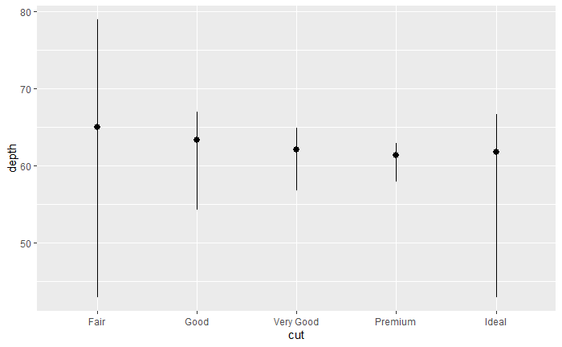

ggplot2 provides more than 20 stats for you to use. Each stat is a function, so you can get help in the usual way, e.g., ?stat_bin.

# 9.5.1 Exercises

What is the default geom associated with stat_summary()? How could you rewrite the previous plot to use that geom function instead of the stat function?

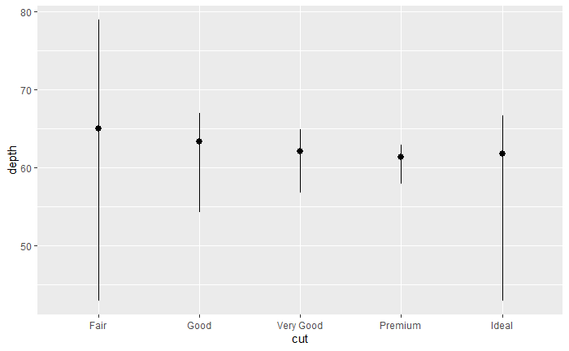

What does geom_col() do? How is it different from geom_bar()?

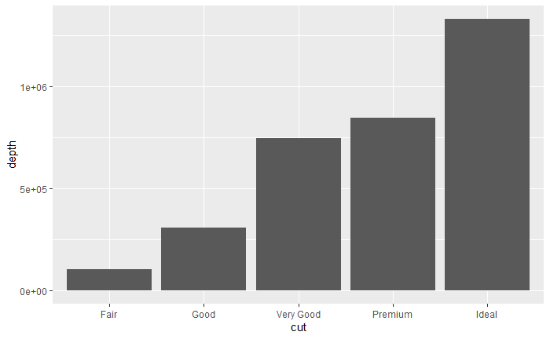

```r
diamonds |>
  ggplot(aes(x = cut, y = depth))+
  geom_col()
```

```r
diamonds |>
  ggplot(aes(x = cut, y = depth))+
  geom_bar()
```

[output not shown]

Most geoms and stats come in pairs that are almost always used in concert. Make a list of all the pairs. What do they have in common? (Hint: Read through the documentation.)

- geom_bar, stat_count
- geom_bin, stat_bin,
- geom_boxplot, stat_boxplot,
- geom_contour, stat_contour,
- geom_count, stat_sum,
- geom_density, stat_density,
- geom_function() stat_function()
- geom_quantile() stat_quantile()
- geom_smooth() stat_smooth()
- What variables does stat_smooth() compute? What arguments control its behavior?

Aids the eye in seeing patterns in the presence of overplotting. geom_smooth() and stat_smooth() are effectively aliases: they both use the same arguments. Use stat_smooth() if you want to display the results with a non-standard geom.

method, formula, se, span, fullrange, orientation

In our proportion bar chart, we needed to set group = 1. Why? In other words, what is the problem with these two graphs?

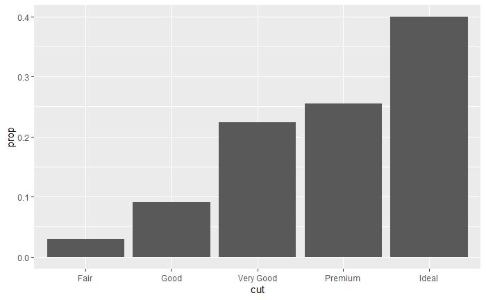

```r
ggplot(diamonds, aes(x = cut, y = after_stat(prop))) +
  geom_bar(aes(group = 1))
```

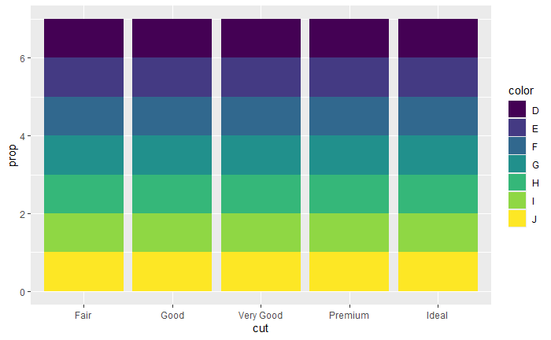

```r
ggplot(diamonds, aes(x = cut, fill = color, y = after_stat(prop))) +
  geom_bar()
```

# 9.6 Position adjustments

There’s one more piece of magic associated with bar charts. You can color a bar chart using either the color aesthetic, or, more usefully, the fill aesthetic:

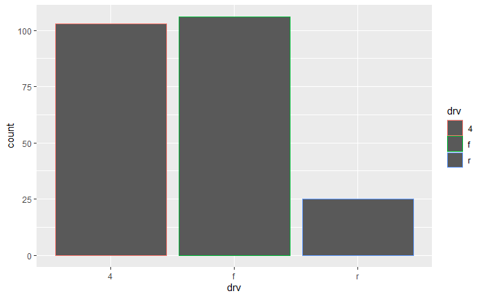

```r
# Left
ggplot(mpg, aes(x = drv, color = drv)) +
  geom_bar()
```

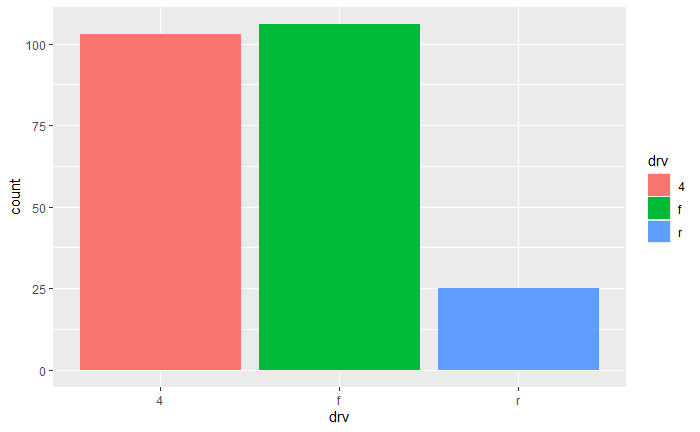

```r
# Right
ggplot(mpg, aes(x = drv, fill = drv)) +
  geom_bar()
```

Note what happens if you map the fill aesthetic to another variable, like class: the bars are automatically stacked. Each colored rectangle represents a combination of drv and class.

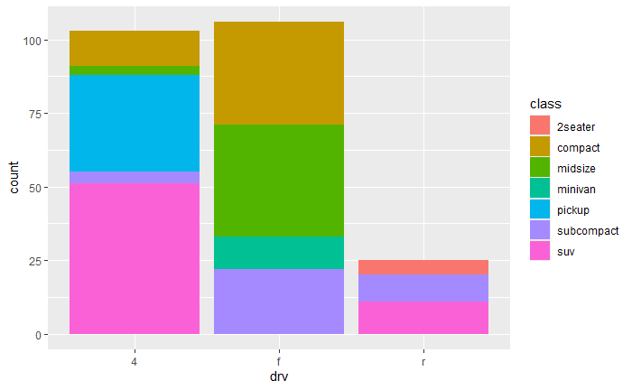

The stacking is performed automatically using the position adjustment specified by the position argument. If you don’t want a stacked bar chart, you can use one of three other options: “identity”, “dodge” or “fill”.

position = “identity” will place each object exactly where it falls in the context of the graph. This is not very useful for bars, because it overlaps them. To see that overlapping we either need to make the bars slightly transparent by setting alpha to a small value, or completely transparent by setting fill = NA.

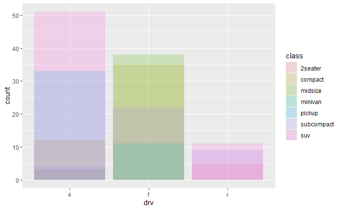

```r
# Left
ggplot(mpg, aes(x = drv, fill = class)) +
  geom_bar(alpha = 1/5, position = "identity")
```

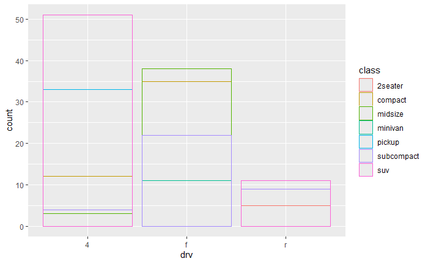

```r
# Right
ggplot(mpg, aes(x = drv, color = class)) +
  geom_bar(fill = NA, position = "identity")
```

The identity position adjustment is more useful for 2d geoms, like points, where it is the default.

position = “fill” works like stacking, but makes each set of stacked bars the same height. This makes it easier to compare proportions across groups.

position = “dodge” places overlapping objects directly beside one another. This makes it easier to compare individual values.

```r
# Left
ggplot(mpg, aes(x = drv, fill = class)) +
  geom_bar(position = "fill")

# Right
ggplot(mpg, aes(x = drv, fill = class)) +
  geom_bar(position = "dodge")
```

[output not shown]

There’s one other type of adjustment that’s not useful for bar charts, but can be very useful for scatterplots. Recall our first scatterplot. Did you notice that the plot displays only 126 points, even though there are 234 observations in the dataset?

The underlying values of hwy and displ are rounded so the points appear on a grid and many points overlap each other. This problem is known as overplotting. This arrangement makes it difficult to see the distribution of the data. Are the data points spread equally throughout the graph, or is there one special combination of hwy and displ that contains 109 values?

You can avoid this gridding by setting the position adjustment to “jitter”. position = “jitter” adds a small amount of random noise to each point. This spreads the points out because no two points are likely to receive the same amount of random noise.

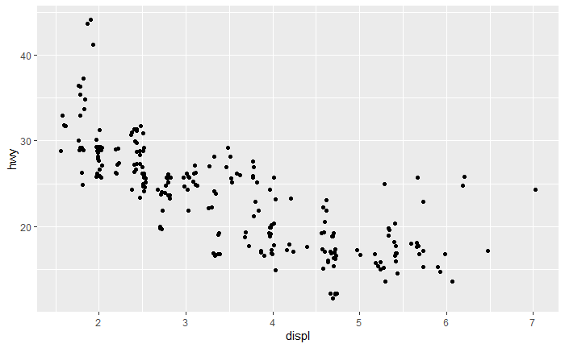

Adding randomness seems like a strange way to improve your plot, but while it makes your graph less accurate at small scales, it makes your graph more revealing at large scales. Because this is such a useful operation, ggplot2 comes with a shorthand for geom_point(position = “jitter”): geom_jitter().

To learn more about a position adjustment, look up the help page associated with each adjustment: ?position_dodge, ?position_fill, ?position_identity, ?position_jitter, and ?position_stack.